# APER Bolivia 2026 — Resultados

Hallazgos del Agricultural Public Expenditure Review · Banco Mundial

Banco Mundial · Universidad EAFIT

14 junio 2026

## Hoja de ruta

**1 · El sector**

Desempeño productivo, estructura por cultivo y bienestar rural.

**2 · El gasto**

Magnitud, meta de Maputo, composición MAFAP y sustitución por crédito.

**3 · Eficiencia técnica**

Frontera departamental con DEA Simar-Wilson.

**4 · Gasto y resultados**

¿El gasto se traduce en productividad y menos pobreza?

**5 · Implicación de política**

El caso del *repurposing*: reasignar, no necesariamente gastar más.

Cifras del panel maestro v12 (1990–2024) y del reporte técnico APER 2026. Identificación asociativa, no causal.

# 1 · El sector

## El acertijo central: gasto que sube, productividad que no

Productividad total de factores · mismo período

+30 %

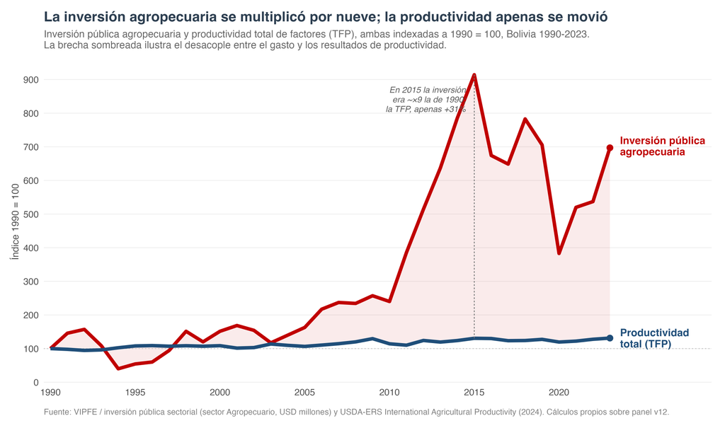

Inversión pública agropecuaria frente a TFP, Bolivia 1990–2023

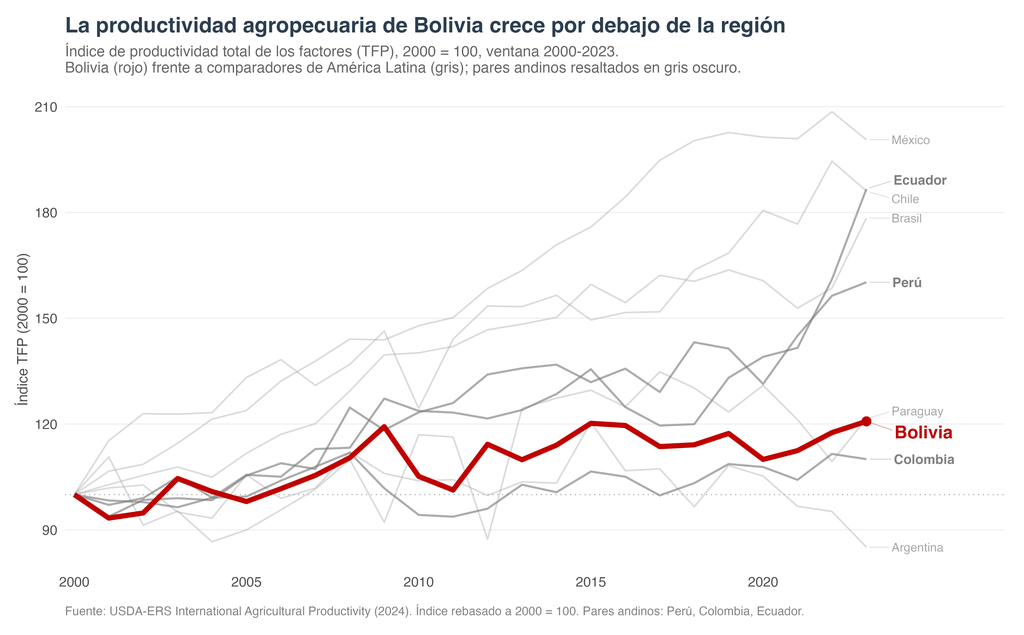

Productividad total de factores — Bolivia frente a LAC

## Crecimiento extensivo: la soya manda, el rendimiento no sigue

Superficie de soya · 2000–2020

×2,4

Rendimiento **+9,6 %** en dos décadas: el sector creció por **expansión de superficie**, no por intensificación.

[figure not shown]

Concentración del valor de producción por cultivo (Pareto), 2006 vs 2023

## Frontera que avanza, bienestar que se revierte

Cobertura natural perdida · 1985–2024

9,4 M ha

64 % en Santa Cruz · hallazgo **F08**

Inseguridad alimentaria (FIES) rural · 2024

74 %

Era 49 % en 2019. La pobreza rural revirtió a **45 %** en 2024 · **F06**

# 2 · El gasto

## Bolivia nunca alcanzó la meta de Maputo

Máximo histórico (1990) · % del gasto público

3,48 %

La meta del **10 %** nunca se logró (**F04**).

Apoyo al productor (PSE) · 2018 — 5° en LAC

5,8 %

Por encima: Brasil, Chile, Colombia, Argentina · **F02**

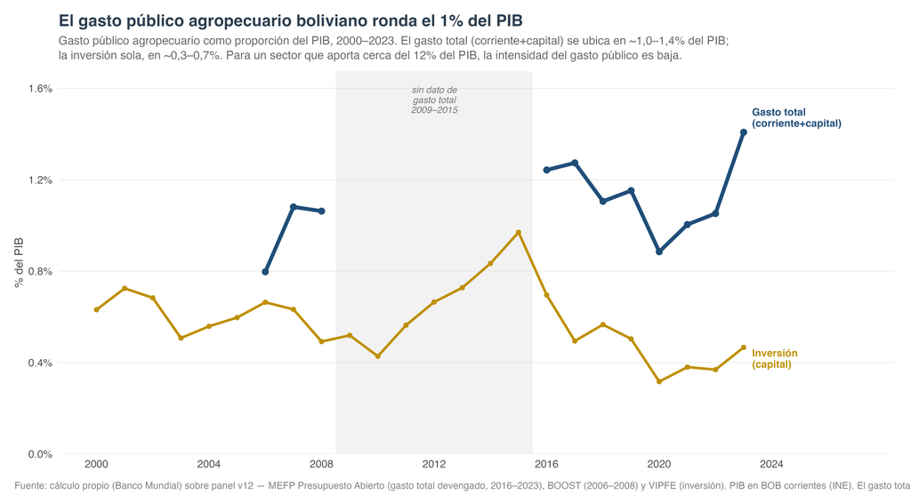

Gasto agropecuario como porcentaje del PIB, Bolivia

## Composición MAFAP: la mitad va a la producción, solo 12 % a bienes públicos

Bienes públicos de alto retorno (I+D, extensión, sanidad)

12 %

Apoyo a la producción **51 %** (USD 205 M, incl. EMAPA ~33 %); riego 27 %; tierras y otros 10 %.

El gasto se concentra en una **intervención de mercado** (EMAPA) y en infraestructura; los bienes públicos de mayor retorno están **crónicamente sub-financiados**.

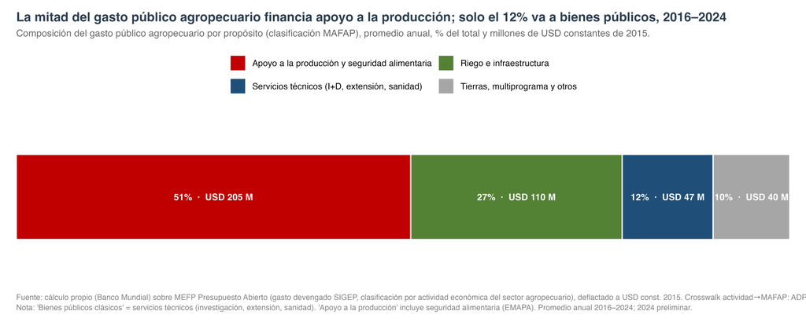

Composición del gasto agropecuario bajo MAFAP-FAO, 2016–2024 (promedio anual)

## Del gasto fiscal al crédito subsidiado (Ley 393)

Cartera agro real · 2010–2024 (USD const. 2015)

×7,1

USD 385 → 2 725 M. El factor nominal de ×11,7 incluye inflación.

La inversión pública cayó de **0,97 % del PIB (2015) a 0,38 % (2021)** · **F05**.

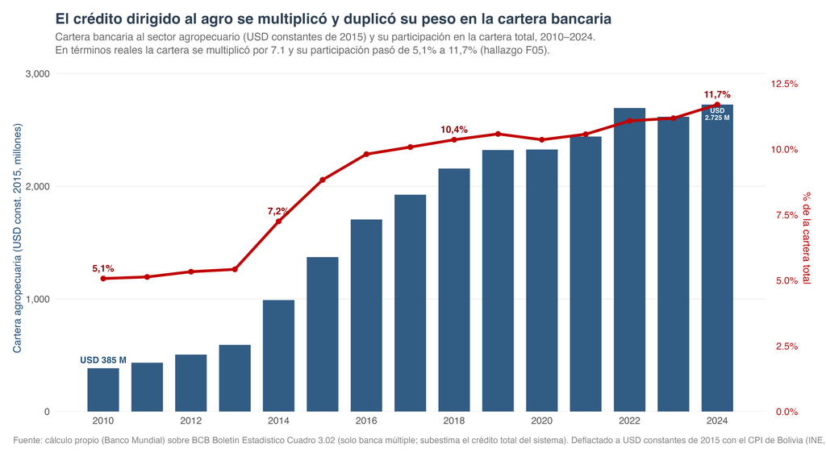

Cartera bancaria agropecuaria, 2010–2024

# 3 · Eficiencia técnica

## La frontera departamental: un gradiente geográfico nítido

Eficiencia media corregida · DEA Simar-Wilson

0,60

Rango 0,22–0,89.

Tierras bajas y valles cerca de la frontera (**Pando 0,85**); altiplano con las mayores brechas (**Potosí 0,27**). **Ningún departamento del altiplano** alcanzó la frontera.

La 2ª etapa (truncada) identifica la **precipitación** como determinante: parte de la brecha es agroecológica, no solo de gestión.

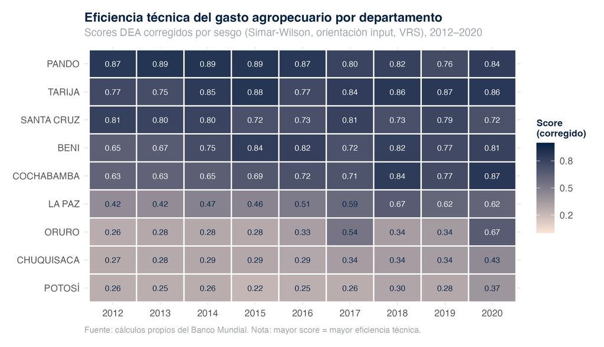

Eficiencia departamental — mapa de calor Simar-Wilson, 2012–2020

# 4 · Gasto y resultados

## ¿El gasto se traduce en resultados? Tres mensajes

**1 · El nivel no mueve los resultados**

A igual departamento, más gasto **no** se asocia de forma estable ni con la productividad de la tierra ni con la pobreza.

**2 · La composición se desplazó**

Apoyo directo a la producción **43 % → 63 %**; riego 27 % → 16 %; servicios técnicos estancados en ~14 %.

**3 · La composición sí importa**

A igual gasto total, más **bienes públicos** se asocia con **menos pobreza** (significativo en pobreza extrema).

Reasignar ~10 puntos del gasto hacia bienes públicos ≈ **2 puntos porcentuales menos de pobreza**.

Panel FE departamento × año, gasto MEFP 2016–2024 e INE. Especificación: ADR-0018. Asociativo, no causal; 9 clústeres.

## Mensaje 1 — el nivel del gasto no mueve los resultados

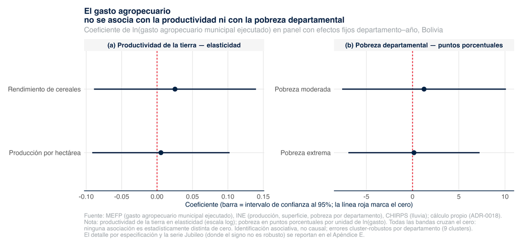

Asociación entre el nivel del gasto agropecuario y los resultados departamentales (panel FE, 2016–2024). Todos los coeficientes cruzan el cero.

## Mensaje 2 — la composición se desplazó

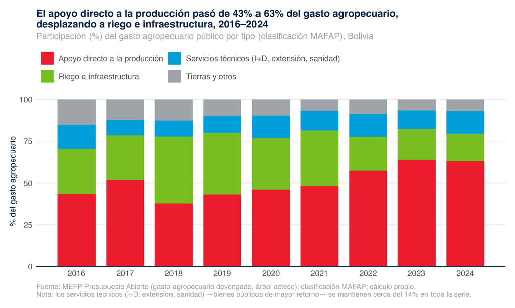

Composición del gasto agropecuario público por tipo de propósito, 2016–2024

## Mensaje 3 — solo los bienes públicos se asocian con menos pobreza

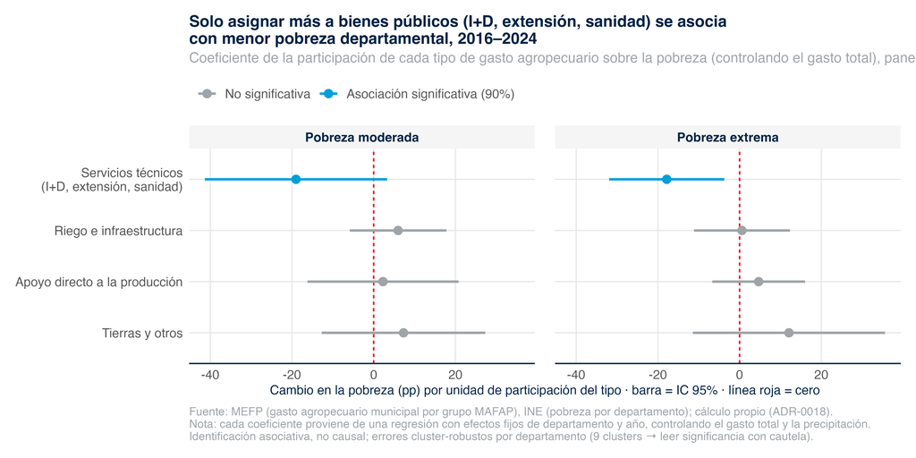

Asociación de cada tipo de gasto con la pobreza departamental, controlando el gasto total (2016–2024)

# 5 · Implicación de política

## El margen está en reasignar, no en gastar más

**La evidencia converge:**

- El **nivel** del gasto no mueve productividad ni pobreza (F01, §5.4).
- La **composición** sí: bienes públicos → menos pobreza.
- Los bienes públicos de mayor retorno (I+D, extensión, sanidad) están **estancados en ~14 %** y en retroceso relativo.
- El patrón dual de protección (NRP) grava exportables y protege alimentarios (F03).

**El caso del *repurposing*:**

A techo fiscal constante, desplazar la composición hacia bienes públicos puede mejorar resultados **sin gastar más**.

Reasignar No necesariamente más gasto

Las opciones técnicas cuantificadas (S01–S03) se desarrollan en el capítulo de recomendaciones del reporte.

**Importante**

El nivel del gasto no es el problema; **su composición** sí lo es. El repurposing hacia bienes públicos es el margen de mejora.

## Gracias

**APER Bolivia 2026** · Agricultural Public Expenditure Review

Banco Mundial · Universidad EAFIT

Sitio del proyecto: jcmunozmora.github.io/bolivia-wb-aper-2026 · Reproducible desde el panel maestro v12.